## Data Wrangling with `dplyr` and `tidyr`

1. Load the nycflights13::flights data set. Does it come formatted as a tibble?

   ```r
   library(tidyverse)
   library(nycflights13)
   data("flights")
   class(flights)
   ```

   ```
   ## [1] "tbl_df"     "tbl"        "data.frame"
   ```

2. Find all flights that
   - had an arrival delay of two or more hours.

   ```r
   filter(flights, arr_delay >= 120)
   ```

   ```
   ## # A tibble: 10,200 x 19
   ##     year month   day dep_time sched_dep_time dep_delay arr_time
   ##    <int> <int> <int>    <int>          <int>     <dbl>    <int>
   ##  1  2013     1     1      811            630       101     1047
   ##  2  2013     1     1      848           1835       853     1001
   ##  3  2013     1     1      957            733       144     1056
   ##  4  2013     1     1     1114            900       134     1447
   ##  5  2013     1     1     1505           1310       115     1638
   ##  6  2013     1     1     1525           1340       105     1831
   ##  7  2013     1     1     1549           1445        64     1912
   ##  8  2013     1     1     1558           1359       119     1718
   ##  9  2013     1     1     1732           1630        62     2028
   ## 10  2013     1     1     1803           1620       103     2008
   ## # ... with 10,190 more rows, and 12 more variables: sched_arr_time <int>,
   ## #   arr_delay <dbl>, carrier <chr>, flight <int>, tailnum <chr>,
   ## #   origin <chr>, dest <chr>, air_time <dbl>, distance <dbl>, hour <dbl>,
   ## #   minute <dbl>, time_hour <dttm>
   ```

   - Flew to Houston (IAH or HOU).

   ```r
    filter(flights, dest %in% c("IAH", "HOU"))
   ```

   ```
   ## # A tibble: 9,313 x 19
   ##     year month   day dep_time sched_dep_time dep_delay arr_time
   ##    <int> <int> <int>    <int>          <int>     <dbl>    <int>
   ##  1  2013     1     1      517            515         2      830
   ##  2  2013     1     1      533            529         4      850
   ##  3  2013     1     1      623            627        -4      933
   ##  4  2013     1     1      728            732        -4     1041
   ##  5  2013     1     1      739            739         0     1104
   ##  6  2013     1     1      908            908         0     1228
   ##  7  2013     1     1     1028           1026         2     1350
   ##  8  2013     1     1     1044           1045        -1     1352
   ##  9  2013     1     1     1114            900       134     1447
   ## 10  2013     1     1     1205           1200         5     1503
   ## # ... with 9,303 more rows, and 12 more variables: sched_arr_time <int>,
   ## #   arr_delay <dbl>, carrier <chr>, flight <int>, tailnum <chr>,
   ## #   origin <chr>, dest <chr>, air_time <dbl>, distance <dbl>, hour <dbl>,
   ## #   minute <dbl>, time_hour <dttm>
   ```

   - were delayed by at least an hour, but made up over 30 minutes in flight.

   ```r
   flights %>% filter(dep_delay > 60 & arr_delay <= dep_delay - 30)
   ```

   ```
   ## # A tibble: 2,046 x 19
   ##     year month   day dep_time sched_dep_time dep_delay arr_time
   ##    <int> <int> <int>    <int>          <int>     <dbl>    <int>
   ##  1  2013     1     1     1716           1545        91     2140
   ##  2  2013     1     1     2205           1720       285       46
   ##  3  2013     1     1     2326           2130       116      131
   ##  4  2013     1     3     1503           1221       162     1803
   ##  5  2013     1     3     1821           1530       171     2131
   ##  6  2013     1     3     1839           1700        99     2056
   ##  7  2013     1     3     1850           1745        65     2148
   ##  8  2013     1     3     1923           1815        68     2036
   ##  9  2013     1     3     1941           1759       102     2246
   ## 10  2013     1     3     1950           1845        65     2228
   ## # ... with 2,036 more rows, and 12 more variables: sched_arr_time <int>,
   ## #   arr_delay <dbl>, carrier <chr>, flight <int>, tailnum <chr>,
   ## #   origin <chr>, dest <chr>, air_time <dbl>, distance <dbl>, hour <dbl>,
   ## #   minute <dbl>, time_hour <dttm>
   ```

   - departed between midnight and 6 am.

   ```r
    filter(flights , between(dep_time, 0, 600) | dep_time == 2400)
   ```

   ```
   ## # A tibble: 9,373 x 19
   ##     year month   day dep_time sched_dep_time dep_delay arr_time
   ##    <int> <int> <int>    <int>          <int>     <dbl>    <int>
   ##  1  2013     1     1      517            515         2      830
   ##  2  2013     1     1      533            529         4      850
   ##  3  2013     1     1      542            540         2      923
   ##  4  2013     1     1      544            545        -1     1004
   ##  5  2013     1     1      554            600        -6      812
   ##  6  2013     1     1      554            558        -4      740
   ##  7  2013     1     1      555            600        -5      913
   ##  8  2013     1     1      557            600        -3      709
   ##  9  2013     1     1      557            600        -3      838
   ## 10  2013     1     1      558            600        -2      753
   ## # ... with 9,363 more rows, and 12 more variables: sched_arr_time <int>,
   ## #   arr_delay <dbl>, carrier <chr>, flight <int>, tailnum <chr>,
   ## #   origin <chr>, dest <chr>, air_time <dbl>, distance <dbl>, hour <dbl>,
   ## #   minute <dbl>, time_hour <dttm>
   ```

3. Which flights took the longest and which the shortest?

   ```r
   slice(flights, which.max(air_time))
   ```

   ```
   ## # A tibble: 1 x 19
   ##    year month   day dep_time sched_dep_time dep_delay arr_time
   ##   <int> <int> <int>    <int>          <int>     <dbl>    <int>
   ## 1  2013     3    17     1337           1335         2     1937
   ## # ... with 12 more variables: sched_arr_time <int>, arr_delay <dbl>,
   ## #   carrier <chr>, flight <int>, tailnum <chr>, origin <chr>, dest <chr>,
   ## #   air_time <dbl>, distance <dbl>, hour <dbl>, minute <dbl>,
   ## #   time_hour <dttm>
   ```

   ```r
   slice(flights, which.min(air_time))
   ```

   ```
   ## # A tibble: 1 x 19
   ##    year month   day dep_time sched_dep_time dep_delay arr_time
   ##   <int> <int> <int>    <int>          <int>     <dbl>    <int>
   ## 1  2013     1    16     1355           1315        40     1442
   ## # ... with 12 more variables: sched_arr_time <int>, arr_delay <dbl>,
   ## #   carrier <chr>, flight <int>, tailnum <chr>, origin <chr>, dest <chr>,
   ## #   air_time <dbl>, distance <dbl>, hour <dbl>, minute <dbl>,
   ## #   time_hour <dttm>
   ```

   ```r
   filter(flights, air_time == max(air_time, na.rm = T))
   ```

   ```
   ## # A tibble: 1 x 19
   ##    year month   day dep_time sched_dep_time dep_delay arr_time
   ##   <int> <int> <int>    <int>          <int>     <dbl>    <int>
   ## 1  2013     3    17     1337           1335         2     1937
   ## # ... with 12 more variables: sched_arr_time <int>, arr_delay <dbl>,
   ## #   carrier <chr>, flight <int>, tailnum <chr>, origin <chr>, dest <chr>,
   ## #   air_time <dbl>, distance <dbl>, hour <dbl>, minute <dbl>,
   ## #   time_hour <dttm>
   ```

   ```r
   filter(flights, air_time == min(air_time, na.rm = T))
   ```

   ```
   ## # A tibble: 2 x 19
   ##    year month   day dep_time sched_dep_time dep_delay arr_time
   ##   <int> <int> <int>    <int>          <int>     <dbl>    <int>
   ## 1  2013     1    16     1355           1315        40     1442
   ## 2  2013     4    13      537            527        10      622
   ## # ... with 12 more variables: sched_arr_time <int>, arr_delay <dbl>,
   ## #   carrier <chr>, flight <int>, tailnum <chr>, origin <chr>, dest <chr>,
   ## #   air_time <dbl>, distance <dbl>, hour <dbl>, minute <dbl>,
   ## #   time_hour <dttm>
   ```

4. Brainstorm as many ways as possible to select `dep_time`, `dep_delay`, `arr_time`, and `arr_delay`.

   ```r
   selection <- c("dep_time", "dep_delay", "arr_time", "arr_delay")
   flights[ ,selection]
   ```

   ```
   ## # A tibble: 336,776 x 4
   ##    dep_time dep_delay arr_time arr_delay
   ##       <int>     <dbl>    <int>     <dbl>
   ##  1      517         2      830        11
   ##  2      533         4      850        20
   ##  3      542         2      923        33
   ##  4      544        -1     1004       -18
   ##  5      554        -6      812       -25
   ##  6      554        -4      740        12
   ##  7      555        -5      913        19
   ##  8      557        -3      709       -14
   ##  9      557        -3      838        -8
   ## 10      558        -2      753         8
   ## # ... with 336,766 more rows
   ```

   ```r
   flights %>% select(selection)
   ```

   ```
   ## # A tibble: 336,776 x 4
   ##    dep_time dep_delay arr_time arr_delay
   ##       <int>     <dbl>    <int>     <dbl>
   ##  1      517         2      830        11
   ##  2      533         4      850        20
   ##  3      542         2      923        33
   ##  4      544        -1     1004       -18
   ##  5      554        -6      812       -25
   ##  6      554        -4      740        12
   ##  7      555        -5      913        19
   ##  8      557        -3      709       -14
   ##  9      557        -3      838        -8
   ## 10      558        -2      753         8
   ## # ... with 336,766 more rows
   ```

5. Create a new variable `first_flight` which takes the value `TRUE` if it is the first flight of the day.

   ```r
   flights <-  mutate(flights, first_flight = if_else(day - lag(day) != 0 | is.na(day - lag(day)), TRUE, FALSE ))
   filter(flights, first_flight == TRUE)
   ```

   ```
   ## # A tibble: 365 x 20
   ##     year month   day dep_time sched_dep_time dep_delay arr_time
   ##    <int> <int> <int>    <int>          <int>     <dbl>    <int>
   ##  1  2013     1     1      517            515         2      830
   ##  2  2013     1     2       42           2359        43      518
   ##  3  2013     1     3       32           2359        33      504
   ##  4  2013     1     4       25           2359        26      505
   ##  5  2013     1     5       14           2359        15      503
   ##  6  2013     1     6       16           2359        17      451
   ##  7  2013     1     7       49           2359        50      531
   ##  8  2013     1     8      454            500        -6      625
   ##  9  2013     1     9        2           2359         3      432
   ## 10  2013     1    10        3           2359         4      426
   ## # ... with 355 more rows, and 13 more variables: sched_arr_time <int>,
   ## #   arr_delay <dbl>, carrier <chr>, flight <int>, tailnum <chr>,
   ## #   origin <chr>, dest <chr>, air_time <dbl>, distance <dbl>, hour <dbl>,
   ## #   minute <dbl>, time_hour <dttm>, first_flight <lgl>
   ```

   ```r
   # A solution using group_by()
   flights %>%
     group_by(year, month, day) %>%
     mutate(first_flight = if_else(row_number() == 1, TRUE, FALSE )) %>%
     select(first_flight)
   ```

   ```
   ## # A tibble: 336,776 x 4
   ## # Groups:   year, month, day [365]
   ##     year month   day first_flight
   ##    <int> <int> <int> <lgl>
   ##  1  2013     1     1 TRUE
   ##  2  2013     1     1 FALSE
   ##  3  2013     1     1 FALSE
   ##  4  2013     1     1 FALSE
   ##  5  2013     1     1 FALSE
   ##  6  2013     1     1 FALSE
   ##  7  2013     1     1 FALSE
   ##  8  2013     1     1 FALSE
   ##  9  2013     1     1 FALSE
   ## 10  2013     1     1 FALSE
   ## # ... with 336,766 more rows
   ```

6. Find out in which district the most incident where reported.

   ```r
   crime <- as_tibble(read.csv(here::here("datasets", "BostonCrime.csv")))
   crime %>%
     group_by(DISTRICT) %>%
     summarise(N = n()) %>%
     arrange(desc(N))
   ```

   ```
   ## # A tibble: 13 x 2
   ##    DISTRICT     N
   ##    <fct>    <int>
   ##  1 B2       67965
   ##  2 C11      57306
   ##  3 D4       55167
   ##  4 B3       48271
   ##  5 A1       47713
   ##  6 C6       31043
   ##  7 D14      26811
   ##  8 E13      23442
   ##  9 E18      23370
   ## 10 E5       17746
   ## 11 A7       17173
   ## 12 A15       8643
   ## 13 ""        2170
   ```

7. Find out in which district the most incident where reported.

   ```r
   crime %>%
     filter(OFFENSE_CODE_GROUP == "Drug Violation") %>%
     group_by(DISTRICT) %>%
     summarise(N = n()) %>%
     arrange(desc(N))
   ```

   ```
   ## # A tibble: 13 x 2
   ##    DISTRICT     N
   ##    <fct>    <int>
   ##  1 B2        3591
   ##  2 C11       2883
   ##  3 A1        2773
   ##  4 D4        2493
   ##  5 C6        2360
   ##  6 B3        2298
   ##  7 E13       1384
   ##  8 A7        1087
   ##  9 E18        930
   ## 10 D14        862
   ## 11 E5         758
   ## 12 A15        434
   ## 13 ""         197
   ```

8. What is the most dangerous hour of the week?

   ```r
   crime %>%
     filter(OFFENSE_CODE_GROUP == "Homicide") %>%
     group_by(HOUR, DAY_OF_WEEK) %>%
     summarise(N = n()) %>%
     arrange(desc(N))
   ```

   ```
   ## # A tibble: 106 x 3
   ## # Groups:   HOUR [24]
   ##     HOUR DAY_OF_WEEK     N
   ##    <int> <fct>       <int>
   ##  1     2 Saturday       10
   ##  2    22 Wednesday      10
   ##  3    23 Saturday        9
   ##  4     0 Saturday        7
   ##  5     0 Thursday        7
   ##  6    18 Wednesday       7
   ##  7    21 Monday          7
   ##  8     0 Sunday          6
   ##  9    10 Tuesday         6
   ## 10    22 Saturday        6
   ## # ... with 96 more rows
   ```

9. Calculate for each district the proportion of motor vehicle accidents to all reported incidents.

   ```r
   crime %>%
     group_by(DISTRICT) %>%
     transmute(prop_accidents = sum(OFFENSE_CODE_GROUP == "Motor Vehicle Accident Response") / n()  )
   ```

   ```
   ## # A tibble: 426,820 x 2
   ## # Groups:   DISTRICT [13]
   ##    DISTRICT prop_accidents
   ##    <fct>             <dbl>
   ##  1 B3               0.107
   ##  2 A1               0.0812
   ##  3 B3               0.107
   ##  4 D4               0.0942
   ##  5 A7               0.116
   ##  6 A1               0.0812
   ##  7 A1               0.0812
   ##  8 E5               0.138
   ##  9 B2               0.126
   ## 10 B3               0.107
   ## # ... with 426,810 more rows
   ```

10. Sort the data set chronologically by year and month. Then take the first 10.000 observations and compute the proportion of incidents where a shooting was involved for each district. Now take a random sample of size 10.000. Is there a noteworthy difference?

    ```r
    set.seed(1245)

    crime %>%
      arrange(desc(YEAR), desc(MONTH)) %>%
      slice(1:10000) %>%
      summarise(shooting = mean(SHOOTING == "Y"))
    ```

    ```
    ## # A tibble: 1 x 1
    ##   shooting
    ##      <dbl>
    ## 1   0.0023
    ```

    ```r
    crime %>%
      sample_n(10000) %>%
      summarise(shooting = mean(SHOOTING == "Y"))
    ```

    ```
    ## # A tibble: 1 x 1
    ##   shooting
    ##      <dbl>
    ## 1   0.0038
    ```

11. Compute the rate for `table2`, and `table4a` + `table4b`.

    ```r
    # Using table 2. Adding the computed data to the table would be inconvenient.
    table2[table2$type == "cases", "count"] / table2[table2$type == "population", "count"]
    ```

    ```
    ##          count
    ## 1 0.0000372741
    ## 2 0.0001294466
    ## 3 0.0002193930
    ## 4 0.0004612363
    ## 5 0.0001667495
    ## 6 0.0001669488
    ```

    ```r
    # Using table4a + `table4b
    table4a[ ,-1] / table4b[ ,-1]
    ```

    ```
    ##           1999         2000
    ## 1 0.0000372741 0.0001294466
    ## 2 0.0002193930 0.0004612363
    ## 3 0.0001667495 0.0001669488
    ```

12. Recreate the plot given by the code below using `table2` instead of `table1`.

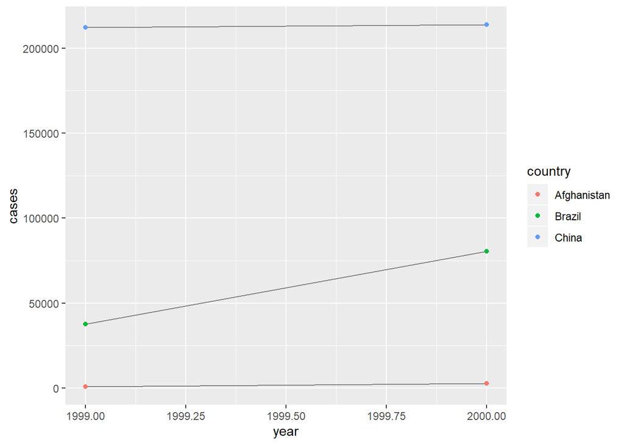

    ```r
    ## Using Table 1
    library(ggplot2)
    ggplot(table1, aes(year, cases)) +
      geom_line(aes(group = country), colour = "grey50") +
      geom_point(aes(colour = country))
    ```

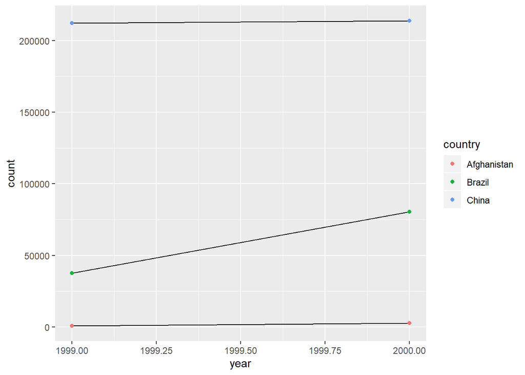

    ```r
    ## Using Table 2
    ggplot(table2 %>% filter(type == "cases"), aes(x = year, y = count)) +
    geom_line(aes( group = country)) +
    geom_point(aes(color = country))
    ```